# Taller 3. Tecnicas para la mejora del aprendizaje y del desempeño de las Redes Neuronales

Nombres: Manuel Sanchez y Allan Ramirez

## Parte 1

```python
import tensorflow as tf
import matplotlib.pyplot as plt
import numpy as np

from tensorflow.keras.datasets import mnist
from tensorflow import keras
from tensorflow.keras import layers
from tensorflow.keras import layers, models, optimizers

(train_images , train_labels) , (test_images , test_labels) = mnist.load_data()


train_images = train_images.reshape((60000, 28 * 28) )
train_images = train_images.astype("float32") / 255
test_images = test_images.reshape((10000, 28 * 28) )
test_images = test_images.astype("float32") / 255

model = keras.Sequential([
    layers.Dense(512, activation ="sigmoid") ,
    layers.Dense(10, activation ="softmax")
])

model.compile(optimizer="SGD",
loss ="SparseCategoricalCrossentropy",
metrics =["accuracy"])

model.fit(train_images, train_labels, epochs=5)

test_loss, test_acc = model.evaluate(test_images, test_labels)
```

```
1875/1875 ━━━━━━━━━━━━━━━━━━━━ 5s 2ms/step - accuracy: 0.5858 - loss: 1.7018
1875/1875 ━━━━━━━━━━━━━━━━━━━━ 4s 2ms/step - accuracy: 0.8474 - loss: 0.6822
1875/1875 ━━━━━━━━━━━━━━━━━━━━ 4s 2ms/step - accuracy: 0.8734 - loss: 0.5027
1875/1875 ━━━━━━━━━━━━━━━━━━━━ 4s 2ms/step - accuracy: 0.8841 - loss: 0.4318
1875/1875 ━━━━━━━━━━━━━━━━━━━━ 5s 2ms/step - accuracy: 0.8920 - loss: 0.3939
313/313 ━━━━━━━━━━━━━━━━━━━━ 1s 1ms/step - accuracy: 0.8844 - loss: 0.4119
```

## Parte I (60 ptos)

1. Utilice su codigo de red neuronal para el problema de reconocimiento de digitos MNIST del Taller 1 para estudiar como varia el desempeño de la red (en terminos generales) en funcion del numero de capas ocultas. Utilice las mismas funciones de activacion para no aumentar el riesgo de sesgos en su analisis. Describa sus observaciones.

El codigo inicial contempla una red que tiene para este caso un modelo secuencial con dos capas densas (Dense):

- La primera capa tiene 512 neuronas con la función de activación sigmoide
- La segunda capa tiene 10 neuronas con la función de activación softmax

Para realizar comparaciones solo iremos aumentando la capas de densas con funcion de activacion sigmoide, entonces trabajaremos otros 4 modelos en donde cada ira aumentando de a una capa oculta y reviseramos sus resultados para determinar como cambia el desempeño de la red.

```python
# Creación de listas para guardar accuracy y modelos
modelos = [str(a) for a in range(1, 5)]
accuracy = [test_acc]

# Modelo 1.2
# Diseño
model12 = keras.Sequential([
    layers.Dense(512, activation="sigmoid"),
    layers.Dense(512, activation="sigmoid"),
    layers.Dense(10, activation="softmax")
])
# Compilacion
model12.compile(optimizer="SGD",
loss ="SparseCategoricalCrossentropy",
metrics =["accuracy"])
# Entrenamiento
model12.fit(train_images, train_labels, epochs=5)
# Guardar accuracy
test_loss, test_acc = model12.evaluate(test_images, test_labels)
accuracy.append(test_acc)

# Modelo 1.3
# Diseño
model13 = keras.Sequential([
    layers.Dense(512, activation="sigmoid"),
    layers.Dense(512, activation="sigmoid"),
    layers.Dense(512, activation="sigmoid"),
    layers.Dense(10, activation="softmax")
])
# Compilacion
model13.compile(optimizer="SGD",
loss ="SparseCategoricalCrossentropy",
metrics =["accuracy"])
# Entrenamiento
model13.fit(train_images, train_labels, epochs=5)
# Guardar accuracy
test_loss, test_acc = model13.evaluate(test_images, test_labels)
accuracy.append(test_acc)

# Modelo 1.4
# Diseño
model14 = keras.Sequential([
    layers.Dense(512, activation="sigmoid"),
    layers.Dense(512, activation="sigmoid"),
    layers.Dense(512, activation="sigmoid"),
    layers.Dense(512, activation="sigmoid"),
    layers.Dense(10, activation="softmax")
])
# Compilacion
model14.compile(optimizer="SGD",
loss ="SparseCategoricalCrossentropy",
metrics =["accuracy"])
# Entrenamiento
model14.fit(train_images, train_labels, epochs=5)
# Guardar accuracy
test_loss, test_acc = model14.evaluate(test_images, test_labels)
accuracy.append(test_acc)

# Modelo 1.5
# Diseño
model15 = keras.Sequential([
    layers.Dense(512, activation="sigmoid"),
    layers.Dense(512, activation="sigmoid"),
    layers.Dense(512, activation="sigmoid"),
    layers.Dense(512, activation="sigmoid"),
    layers.Dense(512, activation="sigmoid"),
    layers.Dense(10, activation="softmax")
])
# Compilacion
model15.compile(optimizer="SGD",
loss ="SparseCategoricalCrossentropy",
metrics =["accuracy"])
# Entrenamiento
model15.fit(train_images, train_labels, epochs=5)
# Guardar accuracy
test_loss, test_acc = model14.evaluate(test_images, test_labels)
accuracy.append(test_acc)
```

```
1875/1875 ━━━━━━━━━━━━━━━━━━━━ 10s 5ms/step - accuracy: 0.2089 - loss: 2.2382
1875/1875 ━━━━━━━━━━━━━━━━━━━━ 9s 5ms/step - accuracy: 0.6297 - loss: 1.6011
1875/1875 ━━━━━━━━━━━━━━━━━━━━ 7s 4ms/step - accuracy: 0.7808 - loss: 0.8968
1875/1875 ━━━━━━━━━━━━━━━━━━━━ 6s 3ms/step - accuracy: 0.8345 - loss: 0.6397
1875/1875 ━━━━━━━━━━━━━━━━━━━━ 7s 4ms/step - accuracy: 0.8602 - loss: 0.5234
313/313 ━━━━━━━━━━━━━━━━━━━━ 1s 2ms/step - accuracy: 0.8582 - loss: 0.5096
1875/1875 ━━━━━━━━━━━━━━━━━━━━ 9s 5ms/step - accuracy: 0.1100 - loss: 2.3093
1875/1875 ━━━━━━━━━━━━━━━━━━━━ 9s 5ms/step - accuracy: 0.1487 - loss: 2.2786
1875/1875 ━━━━━━━━━━━━━━━━━━━━ 9s 5ms/step - accuracy: 0.2675 - loss: 2.2093
1875/1875 ━━━━━━━━━━━━━━━━━━━━ 8s 4ms/step - accuracy: 0.4379 - loss: 1.9152
1875/1875 ━━━━━━━━━━━━━━━━━━━━ 9s 5ms/step - accuracy: 0.6052 - loss: 1.3323
313/313 ━━━━━━━━━━━━━━━━━━━━ 1s 2ms/step - accuracy: 0.6916 - loss: 1.0365
1875/1875 ━━━━━━━━━━━━━━━━━━━━ 12s 6ms/step - accuracy: 0.1050 - loss: 2.3142
1875/1875 ━━━━━━━━━━━━━━━━━━━━ 11s 6ms/step - accuracy: 0.1046 - loss: 2.3103
1875/1875 ━━━━━━━━━━━━━━━━━━━━ 10s 5ms/step - accuracy: 0.1071 - loss: 2.3089
1875/1875 ━━━━━━━━━━━━━━━━━━━━ 12s 6ms/step - accuracy: 0.1132 - loss: 2.3044
1875/1875 ━━━━━━━━━━━━━━━━━━━━ 13s 7ms/step - accuracy: 0.1153 - loss: 2.3022
313/313 ━━━━━━━━━━━━━━━━━━━━ 1s 3ms/step - accuracy: 0.0924 - loss: 2.3057
1875/1875 ━━━━━━━━━━━━━━━━━━━━ 14s 7ms/step - accuracy: 0.1005 - loss: 2.3149
1875/1875 ━━━━━━━━━━━━━━━━━━━━ 13s 7ms/step - accuracy: 0.1028 - loss: 2.3114
1875/1875 ━━━━━━━━━━━━━━━━━━━━ 18s 10ms/step - accuracy: 0.1043 - loss: 2.3118
1875/1875 ━━━━━━━━━━━━━━━━━━━━ 17s 9ms/step - accuracy: 0.1015 - loss: 2.3112
1875/1875 ━━━━━━━━━━━━━━━━━━━━ 16s 9ms/step - accuracy: 0.1030 - loss: 2.3106
313/313 ━━━━━━━━━━━━━━━━━━━━ 1s 3ms/step - accuracy: 0.0924 - loss: 2.3057
```

Ahora bien esta parte hemos creado los otros 4 modelos (tienen desde 1 capa oculta a 5 capas ocultas) y tambien se han guardado sus metricas de desempeño para comparar, vamos a visualizar estas medidas para poder escribir nuestras observaciones.

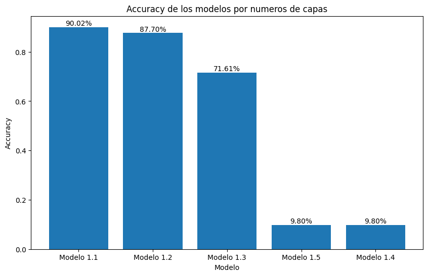

```python
# Crear la figura y establecer el tamaño
plt.figure(figsize=(10, 6))

model_names = [f'Modelo 1.{i}' for i in range(1, 6)]

# Ordenar los modelos y las accuracies de mayor a menor
accuracy_sorted, model_names_sorted = zip(*sorted(zip(accuracy, model_names), reverse=True))

# Graficar el gráfico de barras
bars = plt.bar(model_names_sorted, accuracy_sorted)

# Agregar título y etiquetas a los ejes
plt.title('Accuracy de los modelos por numeros de capas')
plt.xlabel('Modelo')
plt.ylabel('Accuracy')

# Agregar los porcentajes en la parte superior de cada barra
for bar, acc in zip(bars, accuracy_sorted):
    yval = bar.get_height()
    plt.text(bar.get_x() + bar.get_width()/2, yval, f'{acc:.2%}', ha='center', va='bottom')

# Mostrar el gráfico
plt.show()
```

Al observar los resultados, podemos concluir que el mejor modelo para continuar trabajando es aquel con *una sola capa oculta sigmoide*. A medida que iteramos la cantidad de capas, notamos un resultado algo contraintuitivo: uno esperaría que al aumentar la cantidad de capas en una red, su rendimiento mejorara. Sin embargo, en este ejercicio observamos lo contrario. La precisión disminuye de forma significativa conforme se agregan más capas ocultas.

Este comportamiento nos lleva a concluir que, en algunos casos, aumentar las capas ocultas no es necesariamente beneficioso, e incluso puede empeorar el rendimiento del modelo. Así, para ciertos problemas, no es necesario añadir más complejidad a la red, ya que podríamos obtener desempeños inferiores. Por lo tanto, para los próximos puntos, seguiremos trabajando con el primer modelo, que contiene una única capa oculta. Este análisis nos demuestra que, a menudo, los ajustes de los modelos se realizan de manera heurística, basados en los resultados observados durante el proceso de experimentación.

1. Investigue como implementar los métodos de regularización L2, L1, y Dropout en las redes neuronales usando TensorFlow/Keras. En la mejor versión de la red que haya encontrado arriba, implemente los métodos de regularización vistos en clase (L2, L1, Dropout). Experimente con diferentes parámetros y describa sus resultados.

```
313/313 ━━━━━━━━━━━━━━━━━━━━ 1s 2ms/step - accuracy: 0.8844 - loss: 0.4119
1875/1875 ━━━━━━━━━━━━━━━━━━━━ 3s 2ms/step - accuracy: 0.8953 - loss: 0.3761
1875/1875 ━━━━━━━━━━━━━━━━━━━━ 7s 4ms/step - accuracy: 0.5142 - loss: 23.4612
1875/1875 ━━━━━━━━━━━━━━━━━━━━ 7s 4ms/step - accuracy: 0.7423 - loss: 1.7399
1875/1875 ━━━━━━━━━━━━━━━━━━━━ 8s 4ms/step - accuracy: 0.7773 - loss: 1.5435
1875/1875 ━━━━━━━━━━━━━━━━━━━━ 7s 4ms/step - accuracy: 0.8053 - loss: 1.4194
1875/1875 ━━━━━━━━━━━━━━━━━━━━ 7s 4ms/step - accuracy: 0.8192 - loss: 1.3325
1875/1875 ━━━━━━━━━━━━━━━━━━━━ 4s 2ms/step - accuracy: 0.8253 - loss: 1.2769
313/313 ━━━━━━━━━━━━━━━━━━━━ 2s 2ms/step - accuracy: 0.8130 - loss: 1.3166
1875/1875 ━━━━━━━━━━━━━━━━━━━━ 7s 4ms/step - accuracy: 0.5589 - loss: 6.9979
1875/1875 ━━━━━━━━━━━━━━━━━━━━ 8s 4ms/step - accuracy: 0.8430 - loss: 3.4094
1875/1875 ━━━━━━━━━━━━━━━━━━━━ 7s 4ms/step - accuracy: 0.8652 - loss: 1.9875
1875/1875 ━━━━━━━━━━━━━━━━━━━━ 7s 4ms/step - accuracy: 0.8773 - loss: 1.3107
1875/1875 ━━━━━━━━━━━━━━━━━━━━ 7s 4ms/step - accuracy: 0.8814 - loss: 0.9854
1875/1875 ━━━━━━━━━━━━━━━━━━━━ 3s 2ms/step - accuracy: 0.8854 - loss: 0.8435
313/313 ━━━━━━━━━━━━━━━━━━━━ 1s 2ms/step - accuracy: 0.8740 - loss: 0.8813
1875/1875 ━━━━━━━━━━━━━━━━━━━━ 8s 4ms/step - accuracy: 0.5576 - loss: 2.3416
1875/1875 ━━━━━━━━━━━━━━━━━━━━ 7s 4ms/step - accuracy: 0.8465 - loss: 1.2817
1875/1875 ━━━━━━━━━━━━━━━━━━━━ 8s 4ms/step - accuracy: 0.8716 - loss: 1.0707
1875/1875 ━━━━━━━━━━━━━━━━━━━━ 8s 4ms/step - accuracy: 0.8843 - loss: 0.9688
1875/1875 ━━━━━━━━━━━━━━━━━━━━ 7s 4ms/step - accuracy: 0.8891 - loss: 0.9055
1875/1875 ━━━━━━━━━━━━━━━━━━━━ 4s 2ms/step - accuracy: 0.8944 - loss: 0.8651
313/313 ━━━━━━━━━━━━━━━━━━━━ 1s 2ms/step - accuracy: 0.8855 - loss: 0.8968
```

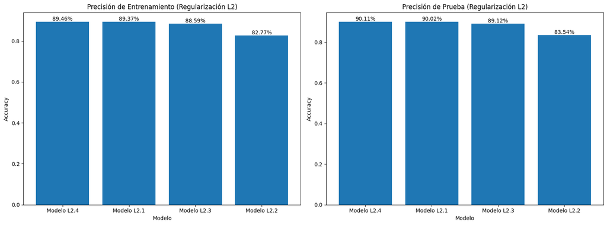

```python
from tensorflow.keras import layers, regularizers

# Inicialización de listas para guardar las precisiones de entrenamiento y prueba
train_acc_L2 = []
test_acc_L2 = []

# Modelo base
test_loss1, test_acc1 = model.evaluate(test_images, test_labels)
train_loss1, train_acc1 = model.evaluate(train_images, train_labels)
train_acc_L2.append(train_acc1)
test_acc_L2.append(test_acc1)

### Regularización L2 Modelo 1
model_l21 = keras.Sequential([
    layers.Dense(512, activation="sigmoid",
                 kernel_regularizer=regularizers.l2(0.1)),  # Regularización L2
    layers.Dense(10, activation="softmax")
])
# Compilación
model_l21.compile(optimizer="SGD",
loss="SparseCategoricalCrossentropy",
metrics=["accuracy"])
# Entrenamiento
model_l21.fit(train_images, train_labels, epochs=5)
# Guardar precisión de entrenamiento y prueba
train_loss1, train_acc1 = model_l21.evaluate(train_images, train_labels)
test_loss1, test_acc1 = model_l21.evaluate(test_images, test_labels)
train_acc_L2.append(train_acc1)
test_acc_L2.append(test_acc1)

### Regularización L2 Modelo 2
model_l22 = keras.Sequential([
    layers.Dense(512, activation="sigmoid",
                 kernel_regularizer=regularizers.l2(0.01)),  # Regularización L2
    layers.Dense(10, activation="softmax")
])
# Compilación
model_l22.compile(optimizer="SGD",
loss="SparseCategoricalCrossentropy",
metrics=["accuracy"])
# Entrenamiento
model_l22.fit(train_images, train_labels, epochs=5)
# Guardar precisión de entrenamiento y prueba
train_loss1, train_acc1 = model_l22.evaluate(train_images, train_labels)
test_loss1, test_acc1 = model_l22.evaluate(test_images, test_labels)
train_acc_L2.append(train_acc1)
test_acc_L2.append(test_acc1)

### Regularización L2 Modelo 3
model_l23 = keras.Sequential([
    layers.Dense(512, activation="sigmoid",
                 kernel_regularizer=regularizers.l2(0.001)),  # Regularización L2
    layers.Dense(10, activation="softmax")
])
# Compilación
model_l23.compile(optimizer="SGD",
loss="SparseCategoricalCrossentropy",
metrics=["accuracy"])
# Entrenamiento
model_l23.fit(train_images, train_labels, epochs=5)
# Guardar precisión de entrenamiento y prueba
train_loss1, train_acc1 = model_l23.evaluate(train_images, train_labels)
test_loss1, test_acc1 = model_l23.evaluate(test_images, test_labels)
train_acc_L2.append(train_acc1)
test_acc_L2.append(test_acc1)

# Crear la figura y una grilla de 1 fila y 2 columnas
fig, axes = plt.subplots(1, 2, figsize=(16, 6))

model_names = [f'Modelo L2.{i}' for i in range(1, 5)]

# Gráfico de precisión de entrenamiento
train_acc_sorted, train_model_names_sorted = zip(*sorted(zip(train_acc_L2, model_names), reverse=True))
bars_train = axes[0].bar(train_model_names_sorted, train_acc_sorted)
axes[0].set_title('Precisión de Entrenamiento (Regularización L2)')
axes[0].set_xlabel('Modelo')
axes[0].set_ylabel('Accuracy')
for bar, acc in zip(bars_train, train_acc_sorted):
    yval = bar.get_height()
    axes[0].text(bar.get_x() + bar.get_width()/2, yval, f'{acc:.2%}', ha='center', va='bottom')

# Gráfico de precisión de prueba
test_acc_sorted, test_model_names_sorted = zip(*sorted(zip(test_acc_L2, model_names), reverse=True))
bars_test = axes[1].bar(test_model_names_sorted, test_acc_sorted)
axes[1].set_title('Precisión de Prueba (Regularización L2)')
axes[1].set_xlabel('Modelo')
axes[1].set_ylabel('Accuracy')
for bar, acc in zip(bars_test, test_acc_sorted):
    yval = bar.get_height()
    axes[1].text(bar.get_x() + bar.get_width()/2, yval, f'{acc:.2%}', ha='center', va='bottom')

# Ajustar el espaciado entre gráficos
plt.tight_layout()

# Mostrar la gráfica
plt.show()
```

En este gráfico podemos observar los resultados obtenidos tras entrenar varios modelos utilizando regularización L2 con diferentes valores de λ= 0.1, 0.01, 0.001 (lambda), es decir, distintos grados de penalización. El objetivo de este análisis es mitigar el sobreajuste sin comprometer de manera significativa la precisión del modelo.

Al incrementar el valor de λ, estamos añadiendo una mayor penalización a los pesos de la red. Por ejemplo, con un λ de 0.1, observamos una penalización más fuerte, lo cual impacta negativamente en la precisión del modelo. Esto nos indica que valores de penalización altos pueden reducir el sobreajuste, pero también afectan el rendimiento.

En cambio, cuando usamos un valor de λ más bajo, como 0.001, la penalización es más suave. Esto permite reducir el sobreajuste sin afectar de manera significativa la precisión del modelo. Con base en estos resultados, podemos concluir que un modelo con regularización L2 y un λ de 0.001 sería una opción adecuada para reemplazar el modelo inicial. Aunque revisemos otros metodos de regulazicion como el L1.

```
313/313 ━━━━━━━━━━━━━━━━━━━━ 1s 2ms/step - accuracy: 0.8844 - loss: 0.4119
1875/1875 ━━━━━━━━━━━━━━━━━━━━ 4s 2ms/step - accuracy: 0.8953 - loss: 0.3761
1875/1875 ━━━━━━━━━━━━━━━━━━━━ 10s 5ms/step - accuracy: 0.1033 - loss: 106.8550
1875/1875 ━━━━━━━━━━━━━━━━━━━━ 8s 5ms/step - accuracy: 0.1030 - loss: 22.3825
1875/1875 ━━━━━━━━━━━━━━━━━━━━ 8s 4ms/step - accuracy: 0.1039 - loss: 22.3830
1875/1875 ━━━━━━━━━━━━━━━━━━━━ 8s 4ms/step - accuracy: 0.1056 - loss: 22.3823
1875/1875 ━━━━━━━━━━━━━━━━━━━━ 8s 4ms/step - accuracy: 0.1044 - loss: 22.3829
1875/1875 ━━━━━━━━━━━━━━━━━━━━ 4s 2ms/step - accuracy: 0.0991 - loss: 22.3717
313/313 ━━━━━━━━━━━━━━━━━━━━ 1s 2ms/step - accuracy: 0.0921 - loss: 22.3755
1875/1875 ━━━━━━━━━━━━━━━━━━━━ 8s 4ms/step - accuracy: 0.2845 - loss: 49.5351
1875/1875 ━━━━━━━━━━━━━━━━━━━━ 8s 4ms/step - accuracy: 0.1077 - loss: 2.5120
1875/1875 ━━━━━━━━━━━━━━━━━━━━ 8s 4ms/step - accuracy: 0.1087 - loss: 2.5122
1875/1875 ━━━━━━━━━━━━━━━━━━━━ 8s 4ms/step - accuracy: 0.1090 - loss: 2.5124
1875/1875 ━━━━━━━━━━━━━━━━━━━━ 9s 5ms/step - accuracy: 0.1077 - loss: 2.5119
1875/1875 ━━━━━━━━━━━━━━━━━━━━ 4s 2ms/step - accuracy: 0.1022 - loss: 2.5128
313/313 ━━━━━━━━━━━━━━━━━━━━ 1s 2ms/step - accuracy: 0.1009 - loss: 2.5161
1875/1875 ━━━━━━━━━━━━━━━━━━━━ 9s 4ms/step - accuracy: 0.5624 - loss: 13.6926
1875/1875 ━━━━━━━━━━━━━━━━━━━━ 8s 4ms/step - accuracy: 0.8363 - loss: 7.0302
1875/1875 ━━━━━━━━━━━━━━━━━━━━ 8s 4ms/step - accuracy: 0.8510 - loss: 3.2999
1875/1875 ━━━━━━━━━━━━━━━━━━━━ 8s 4ms/step - accuracy: 0.8488 - loss: 1.6764
1875/1875 ━━━━━━━━━━━━━━━━━━━━ 8s 4ms/step - accuracy: 0.8477 - loss: 1.3309
1875/1875 ━━━━━━━━━━━━━━━━━━━━ 4s 2ms/step - accuracy: 0.8539 - loss: 1.2352
313/313 ━━━━━━━━━━━━━━━━━━━━ 1s 2ms/step - accuracy: 0.8390 - loss: 1.2711
```

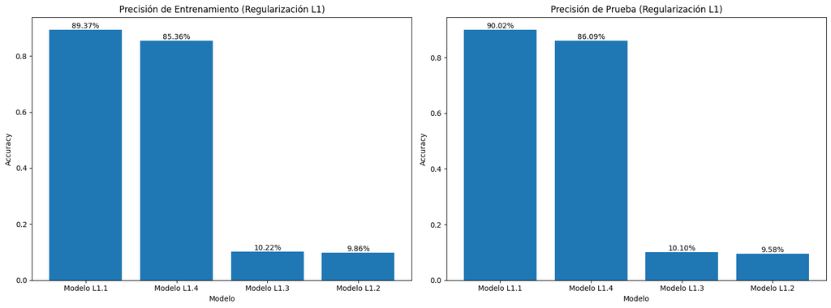

```python
# Inicialización de listas para guardar las precisiones de entrenamiento y prueba
train_acc_L1 = []
test_acc_L1 = []

# Modelo base
test_loss1, test_acc1 = model.evaluate(test_images, test_labels)
train_loss1, train_acc1 = model.evaluate(train_images, train_labels)
train_acc_L1.append(train_acc1)
test_acc_L1.append(test_acc1)

### Regularización L1 Modelo 1
model_l11 = keras.Sequential([
    layers.Dense(512, activation="sigmoid",
                 kernel_regularizer=regularizers.l1(0.1)),  # Regularización L2
    layers.Dense(10, activation="softmax")
])
# Compilación
model_l11.compile(optimizer="SGD",
loss="SparseCategoricalCrossentropy",
metrics=["accuracy"])
# Entrenamiento
model_l11.fit(train_images, train_labels, epochs=5)
# Guardar precisión de entrenamiento y prueba
train_loss1, train_acc1 = model_l11.evaluate(train_images, train_labels)
test_loss1, test_acc1 = model_l11.evaluate(test_images, test_labels)
train_acc_L1.append(train_acc1)
test_acc_L1.append(test_acc1)

### Regularización L1 Modelo 2
model_l12 = keras.Sequential([
    layers.Dense(512, activation="sigmoid",
                 kernel_regularizer=regularizers.l1(0.01)),  # Regularización L2
    layers.Dense(10, activation="softmax")
])
# Compilación
model_l12.compile(optimizer="SGD",
loss="SparseCategoricalCrossentropy",
metrics=["accuracy"])
# Entrenamiento
model_l12.fit(train_images, train_labels, epochs=5)
# Guardar precisión de entrenamiento y prueba
train_loss1, train_acc1 = model_l12.evaluate(train_images, train_labels)
test_loss1, test_acc1 = model_l12.evaluate(test_images, test_labels)
train_acc_L1.append(train_acc1)
test_acc_L1.append(test_acc1)

### Regularización L1 Modelo 3
model_l13 = keras.Sequential([
    layers.Dense(512, activation="sigmoid",
                 kernel_regularizer=regularizers.l1(0.001)),  # Regularización L2
    layers.Dense(10, activation="softmax")
])
# Compilación
model_l13.compile(optimizer="SGD",
loss="SparseCategoricalCrossentropy",
metrics=["accuracy"])
# Entrenamiento
model_l13.fit(train_images, train_labels, epochs=5)
# Guardar precisión de entrenamiento y prueba
train_loss1, train_acc1 = model_l13.evaluate(train_images, train_labels)
test_loss1, test_acc1 = model_l13.evaluate(test_images, test_labels)
train_acc_L1.append(train_acc1)
test_acc_L1.append(test_acc1)

# Crear la figura y una grilla de 1 fila y 2 columnas
fig, axes = plt.subplots(1, 2, figsize=(16, 6))

model_names = [f'Modelo L1.{i}' for i in range(1, 5)]

# Gráfico de precisión de entrenamiento
train_acc_sorted, train_model_names_sorted = zip(*sorted(zip(train_acc_L1, model_names), reverse=True))
bars_train = axes[0].bar(train_model_names_sorted, train_acc_sorted)
axes[0].set_title('Precisión de Entrenamiento (Regularización L1)')
axes[0].set_xlabel('Modelo')
axes[0].set_ylabel('Accuracy')
for bar, acc in zip(bars_train, train_acc_sorted):
    yval = bar.get_height()
    axes[0].text(bar.get_x() + bar.get_width()/2, yval, f'{acc:.2%}', ha='center', va='bottom')

# Gráfico de precisión de prueba
test_acc_sorted, test_model_names_sorted = zip(*sorted(zip(test_acc_L1, model_names), reverse=True))
bars_test = axes[1].bar(test_model_names_sorted, test_acc_sorted)
axes[1].set_title('Precisión de Prueba (Regularización L1)')
axes[1].set_xlabel('Modelo')
axes[1].set_ylabel('Accuracy')
for bar, acc in zip(bars_test, test_acc_sorted):
    yval = bar.get_height()
    axes[1].text(bar.get_x() + bar.get_width()/2, yval, f'{acc:.2%}', ha='center', va='bottom')

# Ajustar el espaciado entre gráficos
plt.tight_layout()

# Mostrar la gráfica
plt.show()
```

Entendiendo cómo funcionan los parámetros de lambda, podemos observar que las penalizaciones grandes afectan significativamente la precisión de los modelos. Esto es particularmente notable cuando aplicamos una penalización elevada, lo cual perjudica el rendimiento de la red. Sin embargo, en el caso de la regularización L1 con un lambda de 0.001, la precisión no se vio tan afectada, aunque, al compararlo con el modelo base, los resultados no superan su buen desempeño.

A continuación, revisemos la regularización por Dropout y sus respectivos resultados, para completar nuestro análisis y determinar que opción más efectiva.

```
313/313 ━━━━━━━━━━━━━━━━━━━━ 1s 2ms/step - accuracy: 0.8844 - loss: 0.4119
1875/1875 ━━━━━━━━━━━━━━━━━━━━ 3s 2ms/step - accuracy: 0.8953 - loss: 0.3761
1875/1875 ━━━━━━━━━━━━━━━━━━━━ 5s 2ms/step - accuracy: 0.3306 - loss: 1.9397
1875/1875 ━━━━━━━━━━━━━━━━━━━━ 4s 2ms/step - accuracy: 0.7117 - loss: 0.9342
1875/1875 ━━━━━━━━━━━━━━━━━━━━ 4s 2ms/step - accuracy: 0.7777 - loss: 0.7129
1875/1875 ━━━━━━━━━━━━━━━━━━━━ 5s 3ms/step - accuracy: 0.8115 - loss: 0.6125
1875/1875 ━━━━━━━━━━━━━━━━━━━━ 5s 3ms/step - accuracy: 0.8336 - loss: 0.5456
1875/1875 ━━━━━━━━━━━━━━━━━━━━ 3s 1ms/step - accuracy: 0.8872 - loss: 0.4130
313/313 ━━━━━━━━━━━━━━━━━━━━ 1s 2ms/step - accuracy: 0.8752 - loss: 0.4497
1875/1875 ━━━━━━━━━━━━━━━━━━━━ 5s 2ms/step - accuracy: 0.3924 - loss: 1.8407
1875/1875 ━━━━━━━━━━━━━━━━━━━━ 5s 3ms/step - accuracy: 0.7674 - loss: 0.8180
1875/1875 ━━━━━━━━━━━━━━━━━━━━ 5s 3ms/step - accuracy: 0.8210 - loss: 0.6088
1875/1875 ━━━━━━━━━━━━━━━━━━━━ 5s 3ms/step - accuracy: 0.8427 - loss: 0.5266
1875/1875 ━━━━━━━━━━━━━━━━━━━━ 5s 3ms/step - accuracy: 0.8574 - loss: 0.4824
1875/1875 ━━━━━━━━━━━━━━━━━━━━ 3s 2ms/step - accuracy: 0.8900 - loss: 0.3952
313/313 ━━━━━━━━━━━━━━━━━━━━ 1s 1ms/step - accuracy: 0.8782 - loss: 0.4309
1875/1875 ━━━━━━━━━━━━━━━━━━━━ 6s 3ms/step - accuracy: 0.4964 - loss: 1.7412
1875/1875 ━━━━━━━━━━━━━━━━━━━━ 5s 3ms/step - accuracy: 0.8226 - loss: 0.7212
1875/1875 ━━━━━━━━━━━━━━━━━━━━ 5s 3ms/step - accuracy: 0.8567 - loss: 0.5323
1875/1875 ━━━━━━━━━━━━━━━━━━━━ 5s 3ms/step - accuracy: 0.8705 - loss: 0.4693
1875/1875 ━━━━━━━━━━━━━━━━━━━━ 5s 3ms/step - accuracy: 0.8809 - loss: 0.4216
1875/1875 ━━━━━━━━━━━━━━━━━━━━ 3s 2ms/step - accuracy: 0.8952 - loss: 0.3804
313/313 ━━━━━━━━━━━━━━━━━━━━ 1s 1ms/step - accuracy: 0.8817 - loss: 0.4130
```

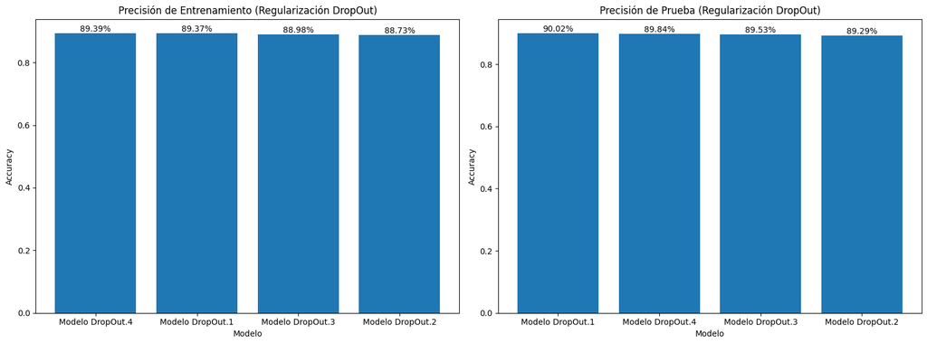

```python
# Inicialización de listas para guardar las precisiones de entrenamiento y prueba
train_acc_DropOut = []
test_acc_DropOut = []

# Modelo base
test_loss1, test_acc1 = model.evaluate(test_images, test_labels)
train_loss1, train_acc1 = model.evaluate(train_images, train_labels)
train_acc_DropOut.append(train_acc1)
test_acc_DropOut.append(test_acc1)

### Regularización DropOut Modelo 2
model_dropout1 = keras.Sequential([
    layers.Dense(512, activation="sigmoid"),
    layers.Dropout(0.5),  # Dropout con tasa del 50%
    layers.Dense(10, activation="softmax")
])
# Compilación
model_dropout1.compile(optimizer="SGD",
loss="SparseCategoricalCrossentropy",
metrics=["accuracy"])
# Entrenamiento
model_dropout1.fit(train_images, train_labels, epochs=5)
# Guardar precisión de entrenamiento y prueba
train_loss1, train_acc1 = model_dropout1.evaluate(train_images, train_labels)
test_loss1, test_acc1 = model_dropout1.evaluate(test_images, test_labels)
train_acc_DropOut.append(train_acc1)
test_acc_DropOut.append(test_acc1)

### Regularización DropOut Modelo 1
model_dropout2 = keras.Sequential([
    layers.Dense(512, activation="sigmoid"),
    layers.Dropout(0.3),  # Dropout con tasa del 50%
    layers.Dense(10, activation="softmax")
])
# Compilación
model_dropout2.compile(optimizer="SGD",
loss="SparseCategoricalCrossentropy",
metrics=["accuracy"])
# Entrenamiento
model_dropout2.fit(train_images, train_labels, epochs=5)
# Guardar precisión de entrenamiento y prueba
train_loss1, train_acc1 = model_dropout2.evaluate(train_images, train_labels)
test_loss1, test_acc1 = model_dropout2.evaluate(test_images, test_labels)
train_acc_DropOut.append(train_acc1)
test_acc_DropOut.append(test_acc1)

### Regularización DropOut Modelo 3
model_dropout3 = keras.Sequential([
    layers.Dense(512, activation="sigmoid"),
    layers.Dropout(0.1),  # Dropout con tasa del 50%
    layers.Dense(10, activation="softmax")
])
# Compilación
model_dropout3.compile(optimizer="SGD",
loss="SparseCategoricalCrossentropy",
metrics=["accuracy"])
# Entrenamiento
model_dropout3.fit(train_images, train_labels, epochs=5)
# Guardar precisión de entrenamiento y prueba
train_loss1, train_acc1 = model_dropout3.evaluate(train_images, train_labels)
test_loss1, test_acc1 = model_dropout3.evaluate(test_images, test_labels)
train_acc_DropOut.append(train_acc1)
test_acc_DropOut.append(test_acc1)

# Crear la figura y una grilla de 1 fila y 2 columnas
fig, axes = plt.subplots(1, 2, figsize=(16, 6))

model_names = [f'Modelo DropOut.{i}' for i in range(1, 5)]

# Gráfico de precisión de entrenamiento
train_acc_sorted, train_model_names_sorted = zip(*sorted(zip(train_acc_DropOut, model_names), reverse=True))
bars_train = axes[0].bar(train_model_names_sorted, train_acc_sorted)
axes[0].set_title('Precisión de Entrenamiento (Regularización DropOut)')
axes[0].set_xlabel('Modelo')
axes[0].set_ylabel('Accuracy')
for bar, acc in zip(bars_train, train_acc_sorted):
    yval = bar.get_height()
    axes[0].text(bar.get_x() + bar.get_width()/2, yval, f'{acc:.2%}', ha='center', va='bottom')

# Gráfico de precisión de prueba
test_acc_sorted, test_model_names_sorted = zip(*sorted(zip(test_acc_DropOut, model_names), reverse=True))
bars_test = axes[1].bar(test_model_names_sorted, test_acc_sorted)
axes[1].set_title('Precisión de Prueba (Regularización DropOut)')
axes[1].set_xlabel('Modelo')
axes[1].set_ylabel('Accuracy')
for bar, acc in zip(bars_test, test_acc_sorted):
    yval = bar.get_height()
    axes[1].text(bar.get_x() + bar.get_width()/2, yval, f'{acc:.2%}', ha='center', va='bottom')

# Ajustar el espaciado entre gráficos
plt.tight_layout()

# Mostrar la gráfica
plt.show()
```

Observando el método de regularización Dropout, que consiste en "apagar" o desactivar aleatoriamente una fracción de las neuronas en una capa durante el entrenamiento, podemos decir que durante cada paso de entrenamiento un subconjunto diferente de neuronas es ignorado al hacer las actualizaciones de los pesos. Hemos experimentado con varias proporciones de Dropout: 50%, 30% y 10%. Aunque no se observan diferencias notables en la precisión al variar este parámetro, destacamos que la precisión en los datos de prueba no se ve afectada significativamente.

Sin embargo, el modelo base sigue mostrando un mejor desempeño, aunque no por un margen considerable. Tras aplicar los diferentes métodos de regularización, podemos concluir que si buscamos un modelo que mejore el rendimiento en comparación con el modelo base, la mejor opción sería el modelo con regularización L2 y una tasa lambda de 0.001. Este será el modelo que utilizaremos para implementar el paso de Early-Stopping.

1. Investigue cómo implementar la técnica de Early-Stopping usando TensorFlow/Keras (como un callback). En la mejor versión de la red que haya encontrado en el Punto 2, implemente el early-stopping. Experimente con diferentes parámetros y describa sus resultados.

```python
from tensorflow.keras.callbacks import EarlyStopping

# Creación del modelo con regularización L2
model_l2_early1 = keras.Sequential([
    layers.Dense(512, activation="sigmoid",
                 kernel_regularizer=regularizers.l2(0.001)),
    layers.Dense(10, activation="softmax")
])

# Compilación del modelo
model_l2_early1.compile(optimizer="SGD",
                 loss="SparseCategoricalCrossentropy",
                 metrics=["accuracy"])

# Definición del callback de Early Stopping
early_stopping = EarlyStopping(monitor='val_loss', patience=2, restore_best_weights=True)

# Entrenamiento con Early Stopping
history = model_l2_early1.fit(train_images, train_labels,
                       validation_split=0.2,  # 20% de los datos para validación
                       epochs=50,  # Número máximo de épocas
                       callbacks=[early_stopping])  # Incluir el callback

# Evaluar el modelo en los datos de prueba
test_loss1, test_acc1 = model_l2_early1.evaluate(test_images, test_labels, verbose=2)

# Imprimir los resultados
print(f'\nPérdida en datos de prueba: {test_loss:.4f}')
print(f'Precisión en datos de prueba: {test_acc:.4f}')
```

[output not shown]

[output cut: 10 more lines]

```
1500/1500 ━━━━━━━━━━━━━━━━━━━━ 6s 4ms/step - accuracy: 0.9098 - loss: 0.6145 - val_accuracy: 0.9147 - val_loss: 0.5900
1500/1500 ━━━━━━━━━━━━━━━━━━━━ 7s 4ms/step - accuracy: 0.9096 - loss: 0.6040 - val_accuracy: 0.9167 - val_loss: 0.5749
1500/1500 ━━━━━━━━━━━━━━━━━━━━ 7s 5ms/step - accuracy: 0.9078 - loss: 0.5896 - val_accuracy: 0.9159 - val_loss: 0.5619
1500/1500 ━━━━━━━━━━━━━━━━━━━━ 7s 5ms/step - accuracy: 0.9121 - loss: 0.5710 - val_accuracy: 0.9172 - val_loss: 0.5473
1500/1500 ━━━━━━━━━━━━━━━━━━━━ 7s 5ms/step - accuracy: 0.9098 - loss: 0.5624 - val_accuracy: 0.9168 - val_loss: 0.5355
1500/1500 ━━━━━━━━━━━━━━━━━━━━ 6s 4ms/step - accuracy: 0.9121 - loss: 0.5477 - val_accuracy: 0.9174 - val_loss: 0.5235
1500/1500 ━━━━━━━━━━━━━━━━━━━━ 6s 4ms/step - accuracy: 0.9128 - loss: 0.5337 - val_accuracy: 0.9174 - val_loss: 0.5137
1500/1500 ━━━━━━━━━━━━━━━━━━━━ 7s 5ms/step - accuracy: 0.9123 - loss: 0.5240 - val_accuracy: 0.9185 - val_loss: 0.5021
1500/1500 ━━━━━━━━━━━━━━━━━━━━ 7s 5ms/step - accuracy: 0.9128 - loss: 0.5151 - val_accuracy: 0.9191 - val_loss: 0.4921
1500/1500 ━━━━━━━━━━━━━━━━━━━━ 7s 5ms/step - accuracy: 0.9158 - loss: 0.4970 - val_accuracy: 0.9180 - val_loss: 0.4833
1500/1500 ━━━━━━━━━━━━━━━━━━━━ 7s 5ms/step - accuracy: 0.9150 - loss: 0.4905 - val_accuracy: 0.9197 - val_loss: 0.4743
1500/1500 ━━━━━━━━━━━━━━━━━━━━ 6s 4ms/step - accuracy: 0.9171 - loss: 0.4802 - val_accuracy: 0.9197 - val_loss: 0.4657
1500/1500 ━━━━━━━━━━━━━━━━━━━━ 7s 4ms/step - accuracy: 0.9158 - loss: 0.4712 - val_accuracy: 0.9189 - val_loss: 0.4578
1500/1500 ━━━━━━━━━━━━━━━━━━━━ 6s 4ms/step - accuracy: 0.9161 - loss: 0.4618 - val_accuracy: 0.9200 - val_loss: 0.4512
313/313 - 1s - 2ms/step - accuracy: 0.9192 - loss: 0.4545
```

Podemos observar que el uso de Early Stopping es eficaz para evitar el sobreajuste, ya que permite que el modelo se detenga automáticamente si no presenta mejoras durante el entrenamiento. Esto previene un ajuste excesivo a los datos de entrenamiento y evita que se ejecuten épocas innecesarias, lo que a su vez ahorra tiempo computacional.

1. ¿Hubo alguna mejora en el desempeño de su red al comparar los resultados del Taller 1 con aquellos obtenidos acá? Describa.

En nuestro Taller 1, nos dimos cuenta que una red que tuvo mejor desempeño que el caso base, una red que tenia una capa 1 con menos neuronas es decir, con 256 neuronas y funcion de activación Relu. Entonces para hacer comparable los resultados y podemos tener una conclusion y una respuesta clara, implementemos esa red del Taller 1 y luego apliquemos los metodos de regularizacion L2, y EarlyStopping para determinar si el desempeño mejora despues de implementar estas nuevas tecnicas.

```python
# Modelo de 1 capa oculta y 256 neuronas
# Diseño
modelT1 = keras.Sequential([
    layers.Dense(256, activation="relu"),
    layers.Dense(10, activation="softmax")
])

# Compilacion
modelT1.compile(optimizer="SGD",
loss ="SparseCategoricalCrossentropy",
metrics =["accuracy"])

# Entrenamiento
modelT1.fit(train_images, train_labels, epochs=5)

# Guardar accuracy
test_lossT1, test_accT1 = modelT1.evaluate(test_images, test_labels)

# Creación del modelo con regularización L2
model_l2_earlyT1 = keras.Sequential([
    layers.Dense(256, activation="relu",
                 kernel_regularizer=regularizers.l2(0.001)),
    layers.Dense(10, activation="softmax")
])

# Compilación del modelo
model_l2_earlyT1.compile(optimizer="SGD",
                 loss="SparseCategoricalCrossentropy",
                 metrics=["accuracy"])

# Definición del callback de Early Stopping
early_stopping = EarlyStopping(monitor='val_loss', patience=3, restore_best_weights=True)

# Entrenamiento con Early Stopping
history = model_l2_earlyT1.fit(train_images, train_labels,
                       validation_split=0.2,  # 20% de los datos para validación
                       epochs=30,  # Número máximo de épocas
                       callbacks=[early_stopping])  # Incluir el callback

# Evaluar el modelo en los datos de prueba
test_lossT12, test_accT12 = model_l2_earlyT1.evaluate(test_images, test_labels, verbose=2)
```

```
1875/1875 ━━━━━━━━━━━━━━━━━━━━ 5s 3ms/step - accuracy: 0.7457 - loss: 1.0140
1875/1875 ━━━━━━━━━━━━━━━━━━━━ 4s 2ms/step - accuracy: 0.9044 - loss: 0.3460
1875/1875 ━━━━━━━━━━━━━━━━━━━━ 3s 2ms/step - accuracy: 0.9177 - loss: 0.2927
1875/1875 ━━━━━━━━━━━━━━━━━━━━ 3s 2ms/step - accuracy: 0.9272 - loss: 0.2585
1875/1875 ━━━━━━━━━━━━━━━━━━━━ 3s 2ms/step - accuracy: 0.9332 - loss: 0.2360
313/313 ━━━━━━━━━━━━━━━━━━━━ 0s 1ms/step - accuracy: 0.9298 - loss: 0.2477
1500/1500 ━━━━━━━━━━━━━━━━━━━━ 4s 2ms/step - accuracy: 0.7233 - loss: 1.4794 - val_accuracy: 0.8991 - val_loss: 0.7516
1500/1500 ━━━━━━━━━━━━━━━━━━━━ 3s 2ms/step - accuracy: 0.8996 - loss: 0.7421 - val_accuracy: 0.9188 - val_loss: 0.6623
1500/1500 ━━━━━━━━━━━━━━━━━━━━ 3s 2ms/step - accuracy: 0.9140 - loss: 0.6621 - val_accuracy: 0.9246 - val_loss: 0.6132
1500/1500 ━━━━━━━━━━━━━━━━━━━━ 3s 2ms/step - accuracy: 0.9225 - loss: 0.6161 - val_accuracy: 0.9325 - val_loss: 0.5741
1500/1500 ━━━━━━━━━━━━━━━━━━━━ 3s 2ms/step - accuracy: 0.9327 - loss: 0.5706 - val_accuracy: 0.9360 - val_loss: 0.5423
1500/1500 ━━━━━━━━━━━━━━━━━━━━ 3s 2ms/step - accuracy: 0.9328 - loss: 0.5459 - val_accuracy: 0.9403 - val_loss: 0.5126
1500/1500 ━━━━━━━━━━━━━━━━━━━━ 3s 2ms/step - accuracy: 0.9389 - loss: 0.5131 - val_accuracy: 0.9450 - val_loss: 0.4867
1500/1500 ━━━━━━━━━━━━━━━━━━━━ 3s 2ms/step - accuracy: 0.9442 - loss: 0.4830 - val_accuracy: 0.9475 - val_loss: 0.4644
1500/1500 ━━━━━━━━━━━━━━━━━━━━ 3s 2ms/step - accuracy: 0.9454 - loss: 0.4617 - val_accuracy: 0.9495 - val_loss: 0.4435
1500/1500 ━━━━━━━━━━━━━━━━━━━━ 3s 2ms/step - accuracy: 0.9495 - loss: 0.4370 - val_accuracy: 0.9507 - val_loss: 0.4240
1500/1500 ━━━━━━━━━━━━━━━━━━━━ 3s 2ms/step - accuracy: 0.9509 - loss: 0.4159 - val_accuracy: 0.9535 - val_loss: 0.4069
1500/1500 ━━━━━━━━━━━━━━━━━━━━ 3s 2ms/step - accuracy: 0.9533 - loss: 0.3968 - val_accuracy: 0.9546 - val_loss: 0.3884
1500/1500 ━━━━━━━━━━━━━━━━━━━━ 3s 2ms/step - accuracy: 0.9558 - loss: 0.3799 - val_accuracy: 0.9571 - val_loss: 0.3724
1500/1500 ━━━━━━━━━━━━━━━━━━━━ 3s 2ms/step - accuracy: 0.9574 - loss: 0.3678 - val_accuracy: 0.9575 - val_loss: 0.3610
1500/1500 ━━━━━━━━━━━━━━━━━━━━ 3s 2ms/step - accuracy: 0.9614 - loss: 0.3452 - val_accuracy: 0.9601 - val_loss: 0.3452
1500/1500 ━━━━━━━━━━━━━━━━━━━━ 4s 2ms/step - accuracy: 0.9621 - loss: 0.3333 - val_accuracy: 0.9603 - val_loss: 0.3349
1500/1500 ━━━━━━━━━━━━━━━━━━━━ 3s 2ms/step - accuracy: 0.9619 - loss: 0.3224 - val_accuracy: 0.9618 - val_loss: 0.3209
1500/1500 ━━━━━━━━━━━━━━━━━━━━ 3s 2ms/step - accuracy: 0.9634 - loss: 0.3091 - val_accuracy: 0.9629 - val_loss: 0.3109
1500/1500 ━━━━━━━━━━━━━━━━━━━━ 3s 2ms/step - accuracy: 0.9665 - loss: 0.2964 - val_accuracy: 0.9636 - val_loss: 0.3002
1500/1500 ━━━━━━━━━━━━━━━━━━━━ 4s 2ms/step - accuracy: 0.9670 - loss: 0.2847 - val_accuracy: 0.9641 - val_loss: 0.2910
1500/1500 ━━━━━━━━━━━━━━━━━━━━ 3s 2ms/step - accuracy: 0.9692 - loss: 0.2757 - val_accuracy: 0.9648 - val_loss: 0.2823
1500/1500 ━━━━━━━━━━━━━━━━━━━━ 3s 2ms/step - accuracy: 0.9693 - loss: 0.2659 - val_accuracy: 0.9650 - val_loss: 0.2737
1500/1500 ━━━━━━━━━━━━━━━━━━━━ 3s 2ms/step - accuracy: 0.9693 - loss: 0.2566 - val_accuracy: 0.9656 - val_loss: 0.2665
1500/1500 ━━━━━━━━━━━━━━━━━━━━ 3s 2ms/step - accuracy: 0.9698 - loss: 0.2491 - val_accuracy: 0.9660 - val_loss: 0.2579
1500/1500 ━━━━━━━━━━━━━━━━━━━━ 3s 2ms/step - accuracy: 0.9720 - loss: 0.2425 - val_accuracy: 0.9668 - val_loss: 0.2510
1500/1500 ━━━━━━━━━━━━━━━━━━━━ 3s 2ms/step - accuracy: 0.9729 - loss: 0.2339 - val_accuracy: 0.9678 - val_loss: 0.2440
1500/1500 ━━━━━━━━━━━━━━━━━━━━ 3s 2ms/step - accuracy: 0.9719 - loss: 0.2299 - val_accuracy: 0.9672 - val_loss: 0.2381
1500/1500 ━━━━━━━━━━━━━━━━━━━━ 3s 2ms/step - accuracy: 0.9759 - loss: 0.2185 - val_accuracy: 0.9681 - val_loss: 0.2318
1500/1500 ━━━━━━━━━━━━━━━━━━━━ 3s 2ms/step - accuracy: 0.9750 - loss: 0.2148 - val_accuracy: 0.9691 - val_loss: 0.2262
1500/1500 ━━━━━━━━━━━━━━━━━━━━ 3s 2ms/step - accuracy: 0.9766 - loss: 0.2056 - val_accuracy: 0.9685 - val_loss: 0.2216
313/313 - 1s - 2ms/step - accuracy: 0.9702 - loss: 0.2166
```

```python
# Imprimir los resultados
print(f'\nPérdida en datos de prueba (Taller1): {test_lossT1:.4f}')
print(f'Precisión en datos de prueba (Taller1): {test_accT1:.4f}')

# Imprimir los resultados
print(f'\nPérdida en datos de prueba (T1 - Regularizacion L2): {test_lossT12:.4f}')
print(f'Precisión en datos de prueba (T1 - Regularizacion L2): {test_accT12:.4f}')
```

[output not shown]

Además, en diferentes tipos de problemas, la regularización L1 o el aumento en la cantidad de capas ocultas pueden ser útiles. El Early Stopping, por su parte, nos permite identificar la época más adecuada para detener el entrenamiento, evitando así gastos computacionales innecesarios.

## Parte 2

### 1.

Utilice su código de red neuronal para el problema de reconocimiento de dígitos MNIST del Taller 2 para estudiar cómo var ́ıa el desempeño de la red (en términos generales) en función del número de capas ocultas. Describa sus observaciones

[figure not shown]

```python
import os
os.chdir('I:/Mi unidad/Estudio/UniAndes/Semestre_3/Modelos avanzados 2/modelos_avanzados_deep_learning')
from Talleres.Taller2.Solucion.parte_practica.main import entrenar_y_medir, load_df
from joblib import Parallel, delayed
from tqdm import tqdm
import pandas as pd

training_data, test_data = load_df()
```

```python
net_configs = []
epochs = 30  # Manteniendo las épocas constantes

# Escenario 1: Sin capas ocultas (Perceptrón simple)
net_configs.append({
    'architecture': [784, 10],  # Sin capas ocultas
    'epochs': epochs,
    'mini_batch_size': 5,  # Mini-batch pequeño
    'eta': 0.1  # Tasa de aprendizaje alta
})

# Escenario 2: 1 capa oculta (30 neuronas)
net_configs.append({
    'architecture': [784, 30, 10],  # 1 capa oculta con 30 neuronas
    'epochs': epochs,
    'mini_batch_size': 10,  # Mini-batch intermedio
    'eta': 0.05  # Tasa de aprendizaje moderada
})

# Escenario 3: 2 capas ocultas (64 y 32 neuronas)
net_configs.append({
    'architecture': [784, 64, 32, 10],  # 2 capas ocultas con 64 y 32 neuronas
    'epochs': epochs,
    'mini_batch_size': 15,  # Mini-batch más grande
    'eta': 0.01  # Tasa de aprendizaje baja
})

# Escenario 4: 3 capas ocultas (128, 64, 32 neuronas)
net_configs.append({
    'architecture': [784, 128, 64, 32, 10],  # 3 capas ocultas con 128, 64 y 32 neuronas
    'epochs': epochs,
    'mini_batch_size': 20,  # Mini-batch más grande
    'eta': 0.001  # Tasa de aprendizaje muy baja
})

# Escenario 5: 4 capas ocultas (256, 128, 64, 32 neuronas)
net_configs.append({
    'architecture': [784, 256, 128, 64, 32, 10],  # 4 capas ocultas con 256, 128, 64 y 32 neuronas
    'epochs': epochs,
    'mini_batch_size': 25,  # Mini-batch muy grande
    'eta': 0.005  # Tasa de aprendizaje moderada
})

# Escenario 6: 1 capa oculta con muchas neuronas
net_configs.append({
    'architecture': [784, 100, 10],  # 1 capa oculta con 100 neuronas
    'epochs': epochs,
    'mini_batch_size': 8,  # Mini-batch pequeño
    'eta': 0.01  # Tasa de aprendizaje baja
})

# Escenario 7: 2 capas ocultas con neuronas más grandes
net_configs.append({
    'architecture': [784, 128, 64, 10],  # 2 capas ocultas con 128 y 64 neuronas
    'epochs': epochs,
    'mini_batch_size': 12,  # Mini-batch intermedio
    'eta': 0.005  # Tasa de aprendizaje moderada
})

# Escenario 8: 3 capas ocultas con muchas neuronas
net_configs.append({
    'architecture': [784, 512, 256, 128, 10],  # 3 capas ocultas con 512, 256 y 128 neuronas
    'epochs': epochs,
    'mini_batch_size': 16,  # Mini-batch intermedio
    'eta': 0.002  # Tasa de aprendizaje muy baja
})

# Escenario 9: Red profunda con capas pequeñas
net_configs.append({
    'architecture': [784, 32, 16, 8, 4, 10],  # 4 capas ocultas pequeñas
    'epochs': epochs,
    'mini_batch_size': 6,  # Mini-batch pequeño
    'eta': 0.05  # Tasa de aprendizaje moderada
})

# Escenario 10: Red con 5 capas ocultas
net_configs.append({
    'architecture': [784, 512, 256, 128, 64, 32, 10],  # 5 capas ocultas
    'epochs': epochs,
    'mini_batch_size': 18,  # Mini-batch grande
    'eta': 0.001  # Tasa de aprendizaje muy baja
})
```

```python
# Ejecutar el proceso en paralelo usando joblib.Parallel
results = Parallel(
    n_jobs=-1, backend='loky', prefer="processes"
)(
    delayed(entrenar_y_medir)(config, training_data, test_data) for config in tqdm(net_configs, desc='Procesando configuraciones')
)
```

```python
# Itera sobre las listas 'net_configs' y 'results' al mismo tiempo
import pandas as pd
for config, red in zip(net_configs, results):
    # Asigna el valor precision a la clave 'precision' en cada diccionario 'config'
    config['precision'] = red[1]
    # Asigna el objeto red a cada diccionario
    config['red'] = red[0]

df_results = pd.DataFrame(net_configs)
df_results
```

|  | architecture | epochs | mini_batch_size | eta | precision | red |
| --- | --- | --- | --- | --- | --- | --- |
| 0 | [784, 10] | 30 | 5 | 0.100 | 75.20 | <Talleres.Taller2.Solucion.parte_practica.netw... |
| 1 | [784, 30, 10] | 30 | 10 | 0.050 | 90.73 | <Talleres.Taller2.Solucion.parte_practica.netw... |
| 2 | [784, 64, 32, 10] | 30 | 15 | 0.010 | 72.00 | <Talleres.Taller2.Solucion.parte_practica.netw... |
| 3 | [784, 128, 64, 32, 10] | 30 | 20 | 0.001 | 22.72 | <Talleres.Taller2.Solucion.parte_practica.netw... |
| 4 | [784, 256, 128, 64, 32, 10] | 30 | 25 | 0.005 | 46.54 | <Talleres.Taller2.Solucion.parte_practica.netw... |
| 5 | [784, 100, 10] | 30 | 8 | 0.010 | 44.62 | <Talleres.Taller2.Solucion.parte_practica.netw... |
| 6 | [784, 128, 64, 10] | 30 | 12 | 0.005 | 63.13 | <Talleres.Taller2.Solucion.parte_practica.netw... |
| 7 | [784, 512, 256, 128, 10] | 30 | 16 | 0.002 | 38.67 | <Talleres.Taller2.Solucion.parte_practica.netw... |
| 8 | [784, 32, 16, 8, 4, 10] | 30 | 6 | 0.050 | 87.63 | <Talleres.Taller2.Solucion.parte_practica.netw... |
| 9 | [784, 512, 256, 128, 64, 32, 10] | 30 | 18 | 0.001 | 20.22 | <Talleres.Taller2.Solucion.parte_practica.netw... |

### 2.

Implemente regularización de tipo L2 y L1, mejore la iniciación de pesos seg ́un lo visto en clase y eval ́ue nuevamente su red (usando diferentes valores de hiperparámetros). ¿Qué puede decir acerca del aprendizaje y desempeño de su red con respecto a los resultados del Taller 2?

```python
from Talleres.Taller3.Solucion.main import entrenar_y_medir

net_configs2 = []
epochs = 30

for reg in ['L1', 'L2']:
    # Configuración 1: Sin capas ocultas (perceptrón simple)
    net_configs2.append({
        'architecture': [784, 10],  # Sin capas ocultas
        'epochs': epochs,
        'mini_batch_size': 5,  # Mini-batch pequeño
        'eta': 0.1,  # Tasa de aprendizaje alta
        'lmbda': 0.0,  # Sin regularización
        'regularization': reg
    })

    # Configuración 2: 1 capa oculta
    net_configs2.append({
        'architecture': [784, 30, 10],  # 1 capa oculta con 30 neuronas
        'epochs': epochs,
        'mini_batch_size': 10,  # Mini-batch intermedio
        'eta': 0.05,  # Tasa de aprendizaje moderada
        'lmbda': 0.01,  # Regularización moderada
        'regularization': reg
    })

    # Configuración 3: 2 capas ocultas
    net_configs2.append({
        'architecture': [784, 64, 32, 10],  # 2 capas ocultas con 64 y 32 neuronas
        'epochs': epochs,
        'mini_batch_size': 15,  # Mini-batch grande
        'eta': 0.01,  # Tasa de aprendizaje baja
        'lmbda': 0.1,  # Regularización alta
        'regularization': reg
    })

    # Configuración 4: 3 capas ocultas
    net_configs2.append({
        'architecture': [784, 128, 64, 32, 10],  # 3 capas ocultas con 128, 64 y 32 neuronas
        'epochs': epochs,
        'mini_batch_size': 20,  # Mini-batch más grande
        'eta': 0.001,  # Tasa de aprendizaje muy baja
        'lmbda': 0.5,  # Regularización fuerte
        'regularization': reg
    })

    # Configuración 5: 4 capas ocultas
    net_configs2.append({
        'architecture': [784, 256, 128, 64, 32, 10],  # 4 capas ocultas con 256, 128, 64 y 32 neuronas
        'epochs': epochs,
        'mini_batch_size': 25,  # Mini-batch muy grande
        'eta': 0.0005,  # Tasa de aprendizaje muy baja
        'lmbda': 1.0,  # Regularización muy fuerte
        'regularization': reg
    })

    # Configuración 6: 1 capa oculta con muchas neuronas
    net_configs2.append({
        'architecture': [784, 100, 10],  # 1 capa oculta con 100 neuronas
        'epochs': epochs,
        'mini_batch_size': 8,  # Mini-batch pequeño
        'eta': 0.01,  # Tasa de aprendizaje baja
        'lmbda': 0.1,  # Regularización alta
        'regularization': reg
    })

    # Configuración 7: 2 capas ocultas con neuronas más grandes
    net_configs2.append({
        'architecture': [784, 128, 64, 10],  # 2 capas ocultas con 128 y 64 neuronas
        'epochs': epochs,
        'mini_batch_size': 12,  # Mini-batch intermedio
        'eta': 0.005,  # Tasa de aprendizaje moderada
        'lmbda': 0.1,  # Regularización alta
        'regularization': reg
    })

    # Configuración 8: 3 capas ocultas con muchas neuronas
    net_configs2.append({
        'architecture': [784, 512, 256, 128, 10],  # 3 capas ocultas con 512, 256 y 128 neuronas
        'epochs': epochs,
        'mini_batch_size': 16,  # Mini-batch intermedio
        'eta': 0.002,  # Tasa de aprendizaje muy baja
        'lmbda': 0.5,  # Regularización fuerte
        'regularization': reg
    })

    # Configuración 9: Red profunda con capas pequeñas
    net_configs2.append({
        'architecture': [784, 32, 16, 8, 4, 10],  # 4 capas ocultas pequeñas
        'epochs': epochs,
        'mini_batch_size': 6,  # Mini-batch pequeño
        'eta': 0.05,  # Tasa de aprendizaje moderada
        'lmbda': 0.01,  # Regularización moderada
        'regularization': reg
    })

    # Configuración 10: Red con 5 capas ocultas
    net_configs2.append({
        'architecture': [784, 512, 256, 128, 64, 32, 10],  # 5 capas ocultas
        'epochs': epochs,
        'mini_batch_size': 18,  # Mini-batch grande
        'eta': 0.001,  # Tasa de aprendizaje muy baja
        'lmbda': 0.5,  # Regularización fuerte
        'regularization': reg
    })
```

```python
# Ejecutar el proceso en paralelo usando joblib.Parallel
results2 = Parallel(
    n_jobs=-1, backend='loky', prefer="processes"
)(
    delayed(entrenar_y_medir)(config, training_data, test_data) for config in tqdm(net_configs2, desc='Procesando configuraciones')
)
```

```python
# Itera sobre las listas 'net_configs' y 'results' al mismo tiempo
import pandas as pd
for config, red in zip(net_configs2, results2):
    # Asigna el valor precision a la clave 'precision' en cada diccionario 'config'
    config['precision'] = red[1]
    # Asigna el objeto red a cada diccionario
    config['red'] = red[0]

df_results2 = pd.DataFrame(net_configs2)
df_results2
```

|  | architecture | epochs | mini_batch_size | eta | lmbda | regularization | precision | red |
| --- | --- | --- | --- | --- | --- | --- | --- | --- |
| 0 | [784, 10] | 30 | 5 | 0.1000 | 0.00 | L1 | 75.13 | <Talleres.Taller3.Solucion.Network_reg.Network... |
| 1 | [784, 30, 10] | 30 | 10 | 0.0500 | 0.01 | L1 | 90.29 | <Talleres.Taller3.Solucion.Network_reg.Network... |
| 2 | [784, 64, 32, 10] | 30 | 15 | 0.0100 | 0.10 | L1 | 79.97 | <Talleres.Taller3.Solucion.Network_reg.Network... |
| 3 | [784, 128, 64, 32, 10] | 30 | 20 | 0.0010 | 0.50 | L1 | 16.02 | <Talleres.Taller3.Solucion.Network_reg.Network... |
| 4 | [784, 256, 128, 64, 32, 10] | 30 | 25 | 0.0005 | 1.00 | L1 | 11.69 | <Talleres.Taller3.Solucion.Network_reg.Network... |
| 5 | [784, 100, 10] | 30 | 8 | 0.0100 | 0.10 | L1 | 45.57 | <Talleres.Taller3.Solucion.Network_reg.Network... |
| 6 | [784, 128, 64, 10] | 30 | 12 | 0.0050 | 0.10 | L1 | 54.51 | <Talleres.Taller3.Solucion.Network_reg.Network... |
| 7 | [784, 512, 256, 128, 10] | 30 | 16 | 0.0020 | 0.50 | L1 | 38.49 | <Talleres.Taller3.Solucion.Network_reg.Network... |
| 8 | [784, 32, 16, 8, 4, 10] | 30 | 6 | 0.0500 | 0.01 | L1 | 77.65 | <Talleres.Taller3.Solucion.Network_reg.Network... |
| 9 | [784, 512, 256, 128, 64, 32, 10] | 30 | 18 | 0.0010 | 0.50 | L1 | 9.74 | <Talleres.Taller3.Solucion.Network_reg.Network... |
| 10 | [784, 10] | 30 | 5 | 0.1000 | 0.00 | L2 | 75.60 | <Talleres.Taller3.Solucion.Network_reg.Network... |
| 11 | [784, 30, 10] | 30 | 10 | 0.0500 | 0.01 | L2 | 81.87 | <Talleres.Taller3.Solucion.Network_reg.Network... |
| 12 | [784, 64, 32, 10] | 30 | 15 | 0.0100 | 0.10 | L2 | 75.59 | <Talleres.Taller3.Solucion.Network_reg.Network... |
| 13 | [784, 128, 64, 32, 10] | 30 | 20 | 0.0010 | 0.50 | L2 | 28.02 | <Talleres.Taller3.Solucion.Network_reg.Network... |
| 14 | [784, 256, 128, 64, 32, 10] | 30 | 25 | 0.0005 | 1.00 | L2 | 20.63 | <Talleres.Taller3.Solucion.Network_reg.Network... |
| 15 | [784, 100, 10] | 30 | 8 | 0.0100 | 0.10 | L2 | 72.03 | <Talleres.Taller3.Solucion.Network_reg.Network... |
| 16 | [784, 128, 64, 10] | 30 | 12 | 0.0050 | 0.10 | L2 | 51.39 | <Talleres.Taller3.Solucion.Network_reg.Network... |
| 17 | [784, 512, 256, 128, 10] | 30 | 16 | 0.0020 | 0.50 | L2 | 30.32 | <Talleres.Taller3.Solucion.Network_reg.Network... |
| 18 | [784, 32, 16, 8, 4, 10] | 30 | 6 | 0.0500 | 0.01 | L2 | 85.63 | <Talleres.Taller3.Solucion.Network_reg.Network... |
| 19 | [784, 512, 256, 128, 64, 32, 10] | 30 | 18 | 0.0010 | 0.50 | L2 | 16.96 | <Talleres.Taller3.Solucion.Network_reg.Network... |

A partir de los resultados observados en ambos casos, se pueden extraer algunos puntos clave: